BACK TO SCHEDULE

- Numeric Summary of Quantitative Data
- Graphical Summary of Quantitative Data

# Numeric Summary of Quantitative Data

Quantitative data is best summarized with the five-number summary and the mean.

- The five-number summary are the minimum, first quartile, median, third quartile and maximum.
- The median is the number located in the middle of the sorted data. Therefore, half of the data is below the *median* and the other half above.
- The first quartile, *(Q1)*, is a number with one quarter (or 25%) of the data below and 75% above.
- Similarly, the third quartile, *(Q3)*, is a number with three quarter (or 75%) of the data below and 25% above.

In R, display the numeric summary of the variable **weight** in the data frame **chickwts**.

> Step 1: Open R

> Step 2: In R Console, type **library(Rcmdr)**, and hit ENTER.

Go to Step 5 if data is already opened

> Step 3: Open data, click on DATA > DATA IN PACKAGES > Read data set from an attached package

> Step 4: Enter name of data set: **chickwts**

> Step 5: Click on STATISTICS > SUMMARIES > NUMERICAL SUMMARIES

> Step 6: Select the variable **weight** and hit OK

```
     mean      sd IQR  0%   25% 50%   75% 100%  n
 261.3099 78.0737 119 108 204.5 258 323.5  423 71
```

Answer the following questions:

- What is the weight range in the sample?
- What is the approximate weight of the heavier chicken in the sample?
- What is the average weight?
- Are there chicken with unusual weight?
- Do the feed supplements help these chicken to growth fast?

# Graphical Summary of Quantitative Data

Plots of quantitative data help to visualize the distribution and unusual observations.

**HISTOGRAM**

- **Histograms** display the shape of the data distribution *(symmetry, skewness, modes)*.
- Histograms are similar to bar charts. Each bar is a **class intervals** with height equal to the interval’s frequency. *(Frequency histogram)*

> In R, click on GRAPHS > HISTOGRAM. Select variable. Choose the OPTION tab to add axes labels and title. Hit OK.

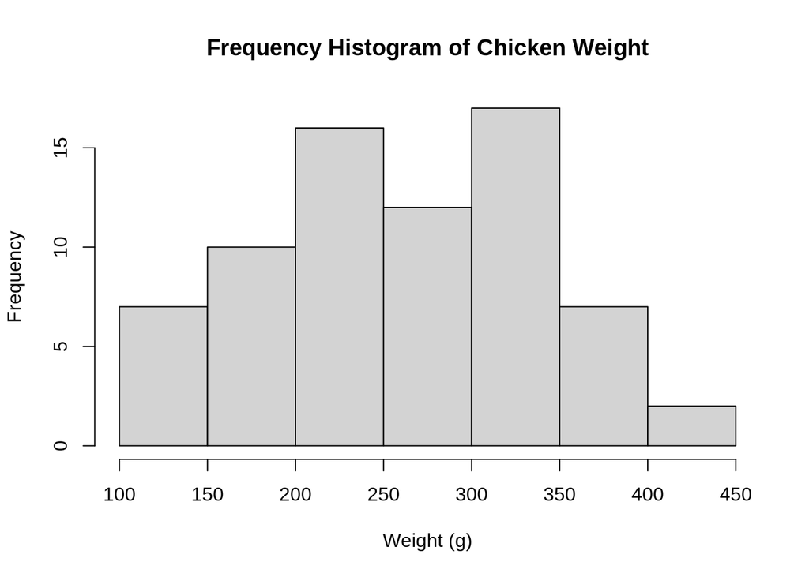

**BOX PLOT**

- A **Box plot** complements the histogram with the visualization of the five-number summary.
- Box plots are effective for the identification of **outliers** *(unusual observations)*

> In R, click on GRAPHS > BOXPLOT. Select variable. Choose the OPTION tab to add axes labels and title. Hit OK.

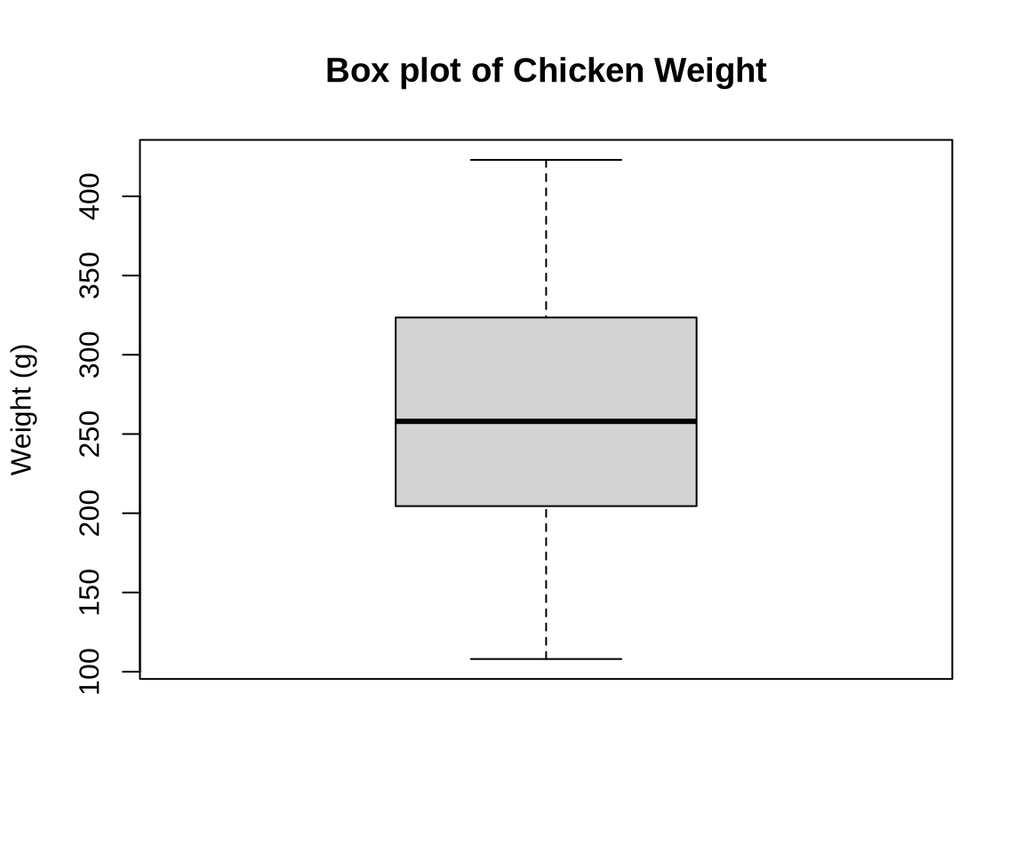